# Advanced Machine Learning - EasyVisa

### Context

Business communities in the United States are facing high demand for human resources, but one of the constant challenges is identifying and attracting the right talent, which is perhaps the most important element in remaining competitive. Companies in the United States look for hard-working, talented, and qualified individuals both locally as well as abroad.

The Immigration and Nationality Act (INA) of the US permits foreign workers to come to the United States to work on either a temporary or permanent basis. The act also protects US workers against adverse impacts on their wages or working conditions by ensuring US employers' compliance with statutory requirements when they hire foreign workers to fill workforce shortages. The immigration programs are administered by the Office of Foreign Labor Certification (OFLC).

OFLC processes job certification applications for employers seeking to bring foreign workers into the United States and grants certifications in those cases where employers can demonstrate that there are not sufficient US workers available to perform the work at wages that meet or exceed the wage paid for the occupation in the area of intended employment.

### Objective

In FY 2016, the OFLC processed 775,979 employer applications for 1,699,957 positions for temporary and permanent labor certifications. This was a nine percent increase in the overall number of processed applications from the previous year. The process of reviewing every case is becoming a tedious task as the number of applicants is increasing every year.

The increasing number of applicants every year calls for a Machine Learning based solution that can help in shortlisting the candidates having higher chances of VISA approval. OFLC has hired the firm EasyVisa for data-driven solutions. You as a data scientist at EasyVisa have to analyze the data provided and, with the help of a classification model:

Facilitate the process of visa approvals. Recommend a suitable profile for the applicants for whom the visa should be certified or denied based on the drivers that significantly influence the case status.

### Data Description

The data contains the different attributes of the employee and the employer. The detailed data dictionary is given below.

case_id: ID of each visa application

continent: Information of continent the employee

education_of_employee: Information of education of the employee

has_job_experience: Does the employee has any job experience? Y= Yes; N = No

requires_job_training: Does the employee require any job training? Y = Yes; N = No

no_of_employees: Number of employees in the employer's company

yr_of_estab: Year in which the employer's company was established

region_of_employment: Information of foreign worker's intended region of employment in the US.

prevailing_wage: Average wage paid to similarly employed workers in a specific occupation in the area of intended employment. The purpose of the prevailing wage is to ensure that the foreign worker is not underpaid compared to other workers offering the same or similar service in the same area of employment.

unit_of_wage: Unit of prevailing wage. Values include Hourly, Weekly, Monthly, and Yearly.

full_time_position: Is the position of work full-time? Y = Full-Time Position; N = Part-Time Position

case_status: Flag indicating if the Visa was certified or denied

### Imports and Data Loading

```python
# Importing necessary library.

import warnings
warnings.filterwarnings("ignore")

import pandas as pd
import numpy as np
import seaborn as sns
import matplotlib.pyplot as plt
sns.set_theme(style="whitegrid")
%matplotlib inline
pd.set_option("display.max_columns", None)
```

```python
# Reading the CSV file.
data = pd.read_csv("EasyVisa.csv")
```

```python
# Making the copy of original data for further analysis.
df = data.copy()
```

```python
df.head()
```

|  | case_id | continent | education_of_employee | has_job_experience | requires_job_training | no_of_employees | yr_of_estab | region_of_employment | prevailing_wage | unit_of_wage | full_time_position | case_status |
| --- | --- | --- | --- | --- | --- | --- | --- | --- | --- | --- | --- | --- |
| 0 | EZYV01 | Asia | High School | N | N | 14513 | 2007 | West | 592.2029 | Hour | Y | Denied |
| 1 | EZYV02 | Asia | Master's | Y | N | 2412 | 2002 | Northeast | 83425.6500 | Year | Y | Certified |
| 2 | EZYV03 | Asia | Bachelor's | N | Y | 44444 | 2008 | West | 122996.8600 | Year | Y | Denied |
| 3 | EZYV04 | Asia | Bachelor's | N | N | 98 | 1897 | West | 83434.0300 | Year | Y | Denied |
| 4 | EZYV05 | Africa | Master's | Y | N | 1082 | 2005 | South | 149907.3900 | Year | Y | Certified |

## Basic Data Understanding

```python
# Checking the shape of the dataset.
df.shape
```

```
(25480, 12)
```

```python
# Checking the dataset info.
df.info()
```

```
<class 'pandas.core.frame.DataFrame'>
RangeIndex: 25480 entries, 0 to 25479
Data columns (total 12 columns):
 #   Column                 Non-Null Count  Dtype
---  ------                 --------------  -----
 0   case_id                25480 non-null  object
 1   continent              25480 non-null  object
 2   education_of_employee  25480 non-null  object
 3   has_job_experience     25480 non-null  object
 4   requires_job_training  25480 non-null  object
 5   no_of_employees        25480 non-null  int64
 6   yr_of_estab            25480 non-null  int64
 7   region_of_employment   25480 non-null  object
 8   prevailing_wage        25480 non-null  float64
 9   unit_of_wage           25480 non-null  object
 10  full_time_position     25480 non-null  object
 11  case_status            25480 non-null  object
dtypes: float64(1), int64(2), object(9)
memory usage: 2.3+ MB
```

### observations:

The dataset has 25,480 records and 12 columns, giving enough data for modeling.

There are no missing values — all columns are complete.

The dataset contains mostly categorical features (9 object columns), so encoding will be required.

Only 3 numerical columns (no_of_employees, yr_of_estab, prevailing_wage), which will need outlier handling and scaling.

Target variable (case_status) is categorical and must be encoded for machine learning.

**Fixing the data types**

```python
# Finding all the object data types columns.
cols = df.select_dtypes(["object"])
cols.columns
```

```
Index(['case_id', 'continent', 'education_of_employee', 'has_job_experience',
       'requires_job_training', 'region_of_employment', 'unit_of_wage',
       'full_time_position', 'case_status'],
      dtype='object')
```

```python
# Converting all the object types columns to category type.
for i in cols.columns:
    df[i] = df[i].astype("category")
```

```python
df.info()
```

```
<class 'pandas.core.frame.DataFrame'>
RangeIndex: 25480 entries, 0 to 25479
Data columns (total 12 columns):
 #   Column                 Non-Null Count  Dtype
---  ------                 --------------  -----
 0   case_id                25480 non-null  category
 1   continent              25480 non-null  category
 2   education_of_employee  25480 non-null  category
 3   has_job_experience     25480 non-null  category
 4   requires_job_training  25480 non-null  category
 5   no_of_employees        25480 non-null  int64
 6   yr_of_estab            25480 non-null  int64
 7   region_of_employment   25480 non-null  category
 8   prevailing_wage        25480 non-null  float64
 9   unit_of_wage           25480 non-null  category
 10  full_time_position     25480 non-null  category
 11  case_status            25480 non-null  category
dtypes: category(9), float64(1), int64(2)
memory usage: 2.0 MB
```

```python
# Checking the summary of categorical columns of the dataset.
df.describe(include=["category"]).T
```

|  | count | unique | top | freq |
| --- | --- | --- | --- | --- |
| case_id | 25480 | 25480 | EZYV9999 | 1 |
| continent | 25480 | 6 | Asia | 16861 |
| education_of_employee | 25480 | 4 | Bachelor's | 10234 |
| has_job_experience | 25480 | 2 | Y | 14802 |
| requires_job_training | 25480 | 2 | N | 22525 |
| region_of_employment | 25480 | 5 | Northeast | 7195 |
| unit_of_wage | 25480 | 4 | Year | 22962 |
| full_time_position | 25480 | 2 | Y | 22773 |
| case_status | 25480 | 2 | Certified | 17018 |

### Observations :

**case_id** has all unique values, confirming it is just an identifier and not useful for modeling.

**Asia** is the most common continent, making up the majority of applications (16,861).

Most applicants hold a **Bachelor’s degree** (10,234).

A large share of applicants have **job experience** (14,802) and do not require job training (22,525).

The **Northeast** region has the highest employment count (7,195).

Most wages are reported **per Year** (22,962).

Majority of positions are **full-time** (22,773).

Most cases are **Certified** (17,018), indicating the dataset is somewhat imbalanced toward approvals.

```python
# Checking the statistical summary numerical columns of the dataset.
df.describe().T
```

|  | count | mean | std | min | 25% | 50% | 75% | max |
| --- | --- | --- | --- | --- | --- | --- | --- | --- |
| no_of_employees | 25480.0 | 5667.043210 | 22877.928848 | -26.0000 | 1022.00 | 2109.00 | 3504.0000 | 602069.00 |
| yr_of_estab | 25480.0 | 1979.409929 | 42.366929 | 1800.0000 | 1976.00 | 1997.00 | 2005.0000 | 2016.00 |
| prevailing_wage | 25480.0 | 74455.814592 | 52815.942327 | 2.1367 | 34015.48 | 70308.21 | 107735.5125 | 319210.27 |

### Observations :

**1. no_of_employees**

Contains invalid values (minimum = –26).

Highly skewed with large outliers (max = 602,069).

Median (2,109) is much lower than mean (5,667), confirming right-skewness.

**2. yr_of_estab**

Values range from 1800 to 2016 — very old years may be data errors.

Most companies are relatively new (median = 1997, 75% = 2005).

**3. prevailing_wage**

Has outliers and possible errors (minimum = 2.13).

Wage distribution is right-skewed, with high variation (max = 319,210).

```python
# Checking the missing values in the dataset
df.isnull().sum()
```

```
case_id                  0
continent                0
education_of_employee    0
has_job_experience       0
requires_job_training    0
no_of_employees          0
yr_of_estab              0
region_of_employment     0
prevailing_wage          0
unit_of_wage             0
full_time_position       0
case_status              0
dtype: int64
```

### Observation:

There is no missing vlaue in the dataset.

```python
# Dropping the column which is not adding any information.
df.drop("case_id", axis = 1, inplace=True)
```

```python
# Let's look at the unique values of all the categories.
cols_cat= df.select_dtypes(["category"])

for i in cols_cat.columns:
    print('Unique values in',i, 'are :')
    print(cols_cat[i].value_counts())
    print('*'*50)
```

```
Unique values in continent are :
continent
Asia             16861
Europe            3732
North America     3292
South America      852
Africa             551
Oceania            192
Name: count, dtype: int64
Unique values in education_of_employee are :
education_of_employee
Bachelor's     10234
Master's        9634
High School     3420
Doctorate       2192
Name: count, dtype: int64
Unique values in has_job_experience are :
has_job_experience
Y    14802
N    10678
Name: count, dtype: int64
Unique values in requires_job_training are :
requires_job_training
N    22525
Y     2955
Name: count, dtype: int64
Unique values in region_of_employment are :
region_of_employment
Northeast    7195
South        7017
West         6586
Midwest      4307
Island        375
Name: count, dtype: int64
Unique values in unit_of_wage are :
unit_of_wage
Year     22962
Hour      2157
Week       272
Month       89
Name: count, dtype: int64
Unique values in full_time_position are :
full_time_position
Y    22773
N     2707
Name: count, dtype: int64
Unique values in case_status are :
case_status
Certified    17018
Denied        8462
Name: count, dtype: int64
```

### Observations :

**continent**

Majority of applications come from Asia (16,861), followed by Europe and North America.

Very few applicants are from Oceania and Africa.

**education_of_employee**

Most applicants hold a Bachelor’s (10,234) or Master’s degree (9,634).

Doctorate and High School categories are comparatively smaller.

**has_job_experience**

More applicants have job experience (14,802) than those without.

**requires_job_training**

Most applicants do not require job training (22,525), showing employers prefer candidates ready to work.

**region_of_employment**

The highest employment requests are in the Northeast (7,195) and South (7,017).

Island region has very few cases.

**unit_of_wage**

Wages are predominantly reported per Year (22,962).

Very few cases use Week or Month as wage units.

**full_time_position**

Most positions are full-time (22,773), with very few part-time roles.

**case_status**

Majority of applications are Certified (17,018), indicating the dataset is imbalanced toward approvals.

## Exploratory Data Analysis (EDA)

### Univariate Analysis

**Below is the user defined function to plot categorical columns for univariate analysis**

```python
def plot_cat(df, column, rotation=45, figsize=(12,5), palette="tab10"):
    """
    Plots a Seaborn countplot and a Matplotlib pie chart for any categorical column.
    - Percentages are shown only in the legend (no overlapping).
    - Only xticks rotation is customizable.
    """
    counts = df[column].value_counts()
    labels = counts.index
    sizes = counts.values
    pcts = sizes / sizes.sum() * 100
    colors = sns.color_palette(palette, len(labels))

    plt.figure(figsize=figsize)

    # ---- Countplot ----
    plt.subplot(1, 2, 1)
    sns.countplot(data=df, x=column, palette=palette)
    plt.title(f"{column} (Countplot)")
    plt.xticks(rotation=rotation)   # only option you asked to customize

    # ---- Pie Chart ----
    plt.subplot(1, 2, 2)
    wedges = plt.pie(
        sizes,
        colors=colors,
        startangle=90,
        textprops={'fontsize': 0}   # no labels inside → avoids overlap
    )[0]
    plt.title(f"{column} (Pie Chart)")
    plt.axis('equal')

    # Legend outside with percentages
    legend_labels = [f"{lab} — {pct:.1f}%" for lab, pct in zip(labels, pcts)]
    plt.legend(
        wedges,
        legend_labels,
        title="Categories",
        loc="center left",
        bbox_to_anchor=(1.05, 0.5)
    )

    plt.tight_layout()
    plt.show()
```

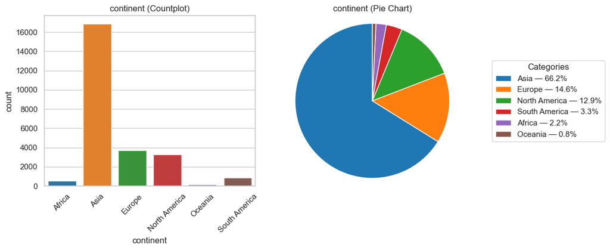

```python
# Plotting the continent variable to see the distribution
plot_cat(df, "continent", rotation = 45)
```

### Observations :

**Asia** dominates the dataset, accounting for **about two-thirds (66.2%)** of all applications — by far the largest contributor.

**Europe (14.6%)** and **North America (12.9%)** form the next major groups but are significantly smaller than Asia.

**South America, Africa,**** and ***Oceania** have very few applications (each below 4%), indicating **low representation** from these regions.

Overall, the distribution is **highly imbalanced**, with a strong concentration of applicants from Asia.

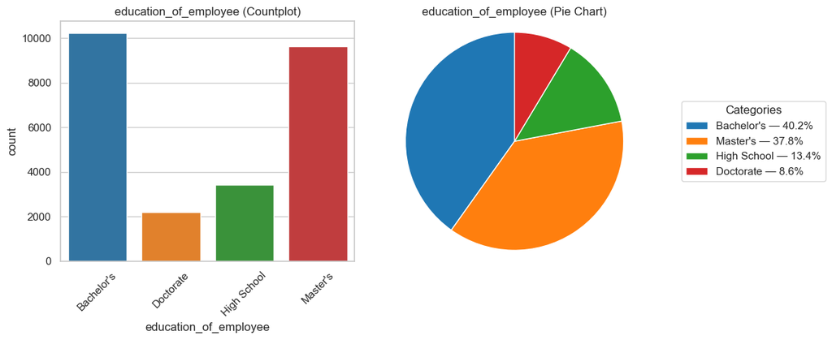

```python
# Plotting the education_of_employee variable to see the distribution
plot_cat(df, "education_of_employee", rotation = 45)
```

### Observations :

**Bachelor’s (40.2%)** and **Master’s (37.8%)** degrees make up the majority of applicants, showing most candidates are well-qualified.

**High School graduates (13.4%)** form a smaller portion, while **Doctorate holders (8.6%)** are the least common.

Overall, the dataset is **dominated by candidates with higher education levels**, indicating employers may prefer skilled and educated workers.

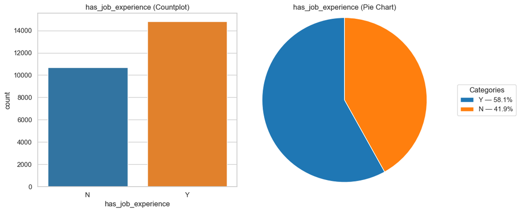

```python
# Plotting the has_job_experience variable to see the distribution
plot_cat(df, "has_job_experience", rotation = 0)
```

### Observations :

A **majority of applicants (58.1%) have job experience**, while **41.9% do not**.

The dataset shows a **moderate imbalance** toward experienced applicants.

This suggests that most candidates applying for the visa come with **prior work experience**, which may be a significant factor in case outcomes.

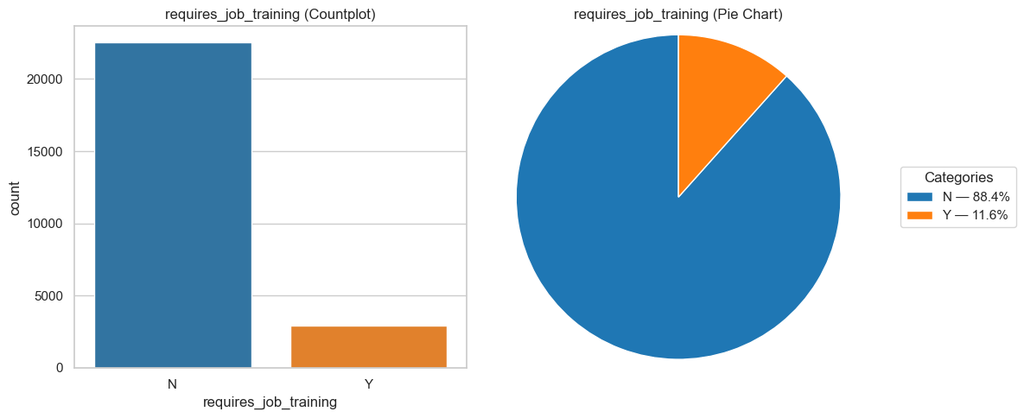

```python
# Plotting the requires_job_training variable to see the distribution
plot_cat(df, "requires_job_training", rotation = 0)
```

### Observations :

A **very large majority of applicants (88.4%) do NOT require job training**, while only **11.6% do**.

This indicates that most candidates are **already skilled or job-ready**, reducing employer training burden.

The distribution is **highly imbalanced**, with "No training required" dominating the dataset.

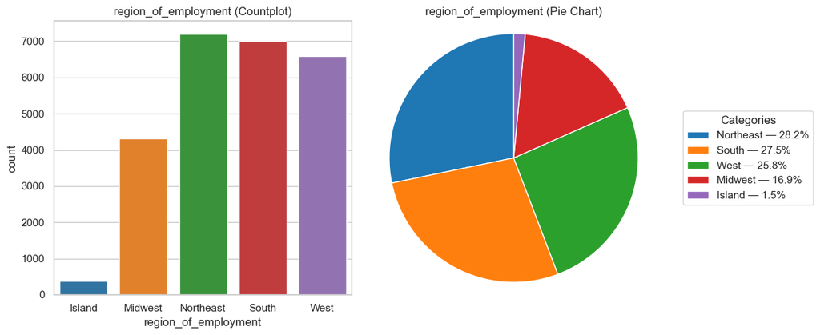

```python
# Plotting the region_of_employment variable to see the distribution
plot_cat(df, "region_of_employment", rotation = 0)
```

### Observations :

The **Northeast, South, and West** regions dominate employment demand, together accounting for more than 80% of the cases.

**Northeast (28.2%)** has the highest share, closely followed by **South (27.5%)** and **West (25.8%)**.

**Midwest (16.9%)** has moderate representation.

**Island region (1.5%)** contributes very few cases, indicating minimal demand compared to other regions.

Overall, employment demand is **concentrated mainly in three regions**, showing clear regional preferences.

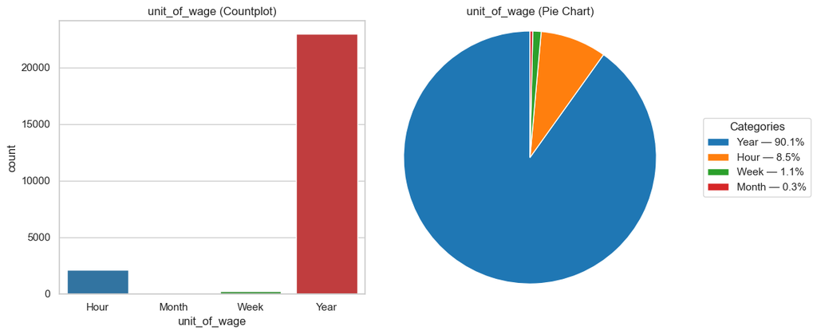

```python
# Plotting the unit_of_wage variable to see the distribution
plot_cat(df, "unit_of_wage", rotation = 0)
```

### Observations :

**Yearly wage units dominate the dataset**, accounting for **90.1%** of all records — this is the standard wage format used in most cases.

**Hourly wages (8.5%)** form a small secondary group.

**Weekly (1.1%)** and **Monthly (0.3%)** wage units are extremely rare.

This shows that the dataset is **highly skewed toward yearly salary reporting**, with other wage formats used only in exceptional cases.

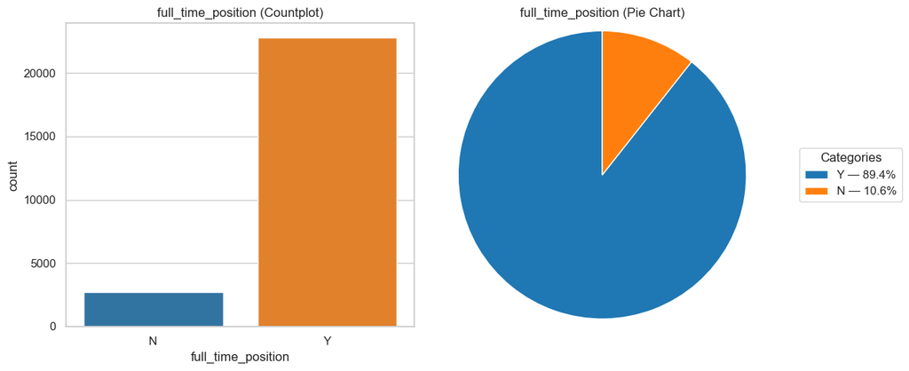

```python
# Plotting the full_time_position variable to see the distribution
plot_cat(df, "full_time_position", rotation = 0)
```

### Observations :

**Full-time positions dominate the dataset**, making up **89.4%** of all cases.

Only **10.6%** of positions are **part-time**, showing they are relatively uncommon.

This indicates that most visa applications are for **full-time employment**, which may align with employer preference and visa approval requirements.

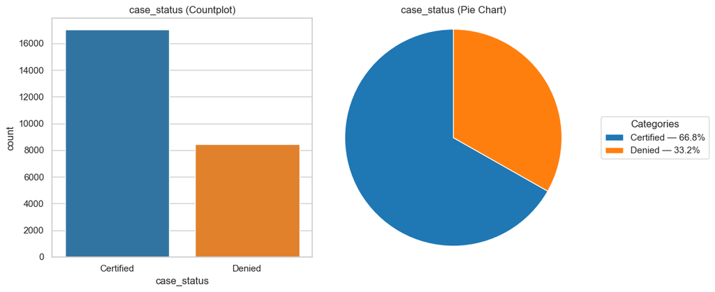

```python
# Plotting the full_time_position variable to see the distribution
plot_cat(df, "case_status", rotation = 0)
```

### Observations :

**Certified cases dominate**, accounting for **66.8%** of all applications.

**Denied cases make up 33.2%**, making the target variable **moderately imbalanced**.

The imbalance indicates that the model may need techniques like **class weighting** or **resampling** to avoid bias toward the majority class.

```python
def plot_num_distribution(df, column, bins = 30, figsize=(12,4)):
    """
    Plots Histogram with KDE and Boxplot for any numerical column.
    """
    plt.figure(figsize=figsize)

    # Histogram
    plt.subplot(1, 2, 1)
    sns.histplot(df[column], kde=True, bins = bins, color="skyblue")
    plt.title(f"Histogram of {column}")

    # Boxplot
    plt.subplot(1, 2, 2)
    sns.boxplot(x=df[column], color="lightgreen")
    plt.title(f"Boxplot of {column}")

    plt.tight_layout()
    plt.show()
```

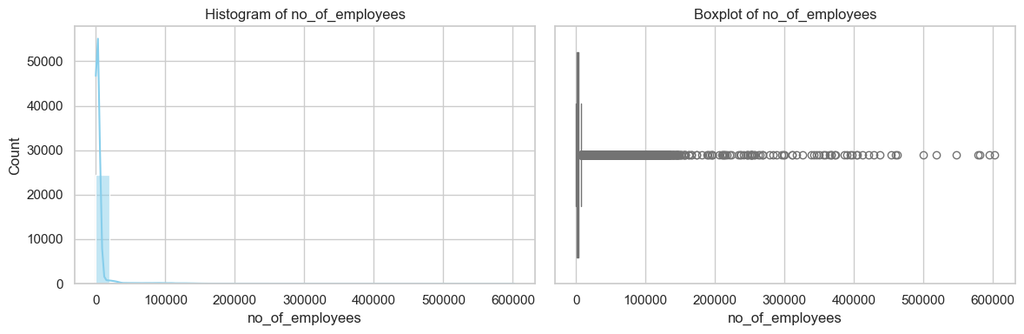

```python
# Plotting the no_of_employees variable to see the distribution.
plot_num_distribution(df, "no_of_employees")
```

### Observations :

The distribution of **no_of_employees is highly right-skewed**, with most companies having a **very low employee count**.

A **long tail with extreme outliers** stretches beyond **600,000 employees**, which heavily impacts the scale.

The boxplot clearly shows **numerous large outliers**, indicating inconsistent or unusual values in the dataset.

This variable likely needs **outlier treatment or log transformation** to make the distribution more normal for modeling.

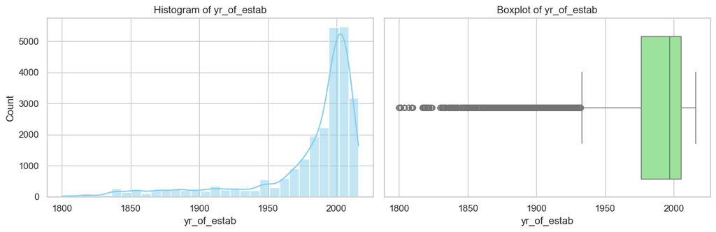

```python
# Plotting the yr_of_estab variable to see the distribution.
plot_num_distribution(df, "yr_of_estab")
```

### Observations :

The **year of establishment** ranges widely, from the **1800s to the 2000s**, indicating the presence of many very old companies in the dataset.

There are many **extreme outliers** in the earlier years (1800–1900), which appear unrealistic for modern businesses and may need **cleaning or capping.**

The boxplot confirms that most companies fall within a **narrow and recent range**, while the old years pull the lower whisker significantly.

```python
# Dataset ontains invalid years (e.g., 1800). Assuming reasonable years for companies are typically 1900–2025.
df.loc[df["yr_of_estab"] < 1900, "yr_of_estab"] = np.nan
df["yr_of_estab"] = df["yr_of_estab"].fillna(df["yr_of_estab"].median())
df["company_age"] = 2025 - df["yr_of_estab"]
```

```python
# Dropping yr_of_estab columns from dataset.
df.drop("yr_of_estab", axis = 1, inplace = True)
```

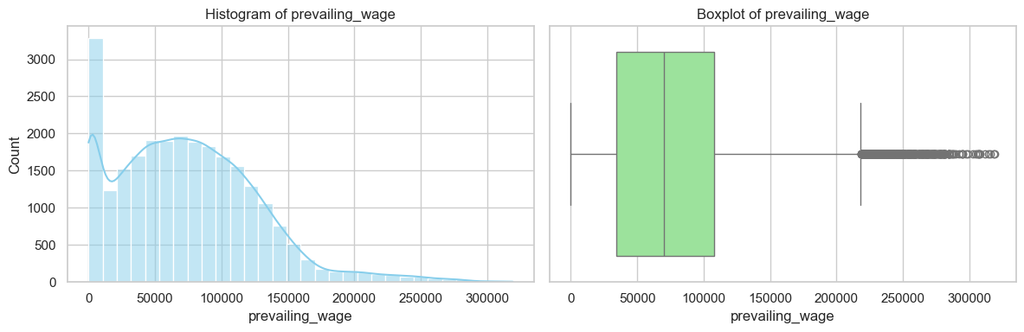

```python
# Plotting the yr_of_estab variable to see the distribution.
plot_num_distribution(df, "prevailing_wage")
```

### Observations:

The **prevailing wage** distribution is highly **right-skewed**, with most wages concentrated between **$30,000 and $120,000**.

There are **numerous extreme outliers**, with wages extending beyond **$300,000**, indicating a wide range of job types and salary levels.

The boxplot highlights a **large number of high-wage outliers**, suggesting potential inconsistencies or highly specialized roles.

The histogram shows multiple peaks, indicating the wage variable may represent **different categories of jobs or industries**.

### Bivariate Analysis

**Below is the user defined function to plot categorical features with target for bivariate analysis.**

```python
def stacked_barplot(df, predictor, target):
    """
    Print the category counts and plot a stacked bar chart

    data: dataframe
    predictor: independent variable
    target: target variable
    """
    count = df[predictor].nunique()
    sorter = df[target].value_counts().index[-1]
    tab1 = pd.crosstab(df[predictor], df[target], margins=True).sort_values(
        by=sorter, ascending=False
    )
    print(tab1)
    print("-" * 120)
    tab = pd.crosstab(data[predictor], df[target], normalize="index").sort_values(
        by=sorter, ascending=False
    )
    tab.plot(kind="bar", stacked=True, figsize=(count + 1, 5))
    plt.legend(
        loc="lower left",
        frameon=False,
    )
    plt.legend(loc="upper left", bbox_to_anchor=(1, 1))
    plt.show()
```

```
case_status    Certified  Denied    All
continent
All                17018    8462  25480
Asia               11012    5849  16861
North America       2037    1255   3292
Europe              2957     775   3732
South America        493     359    852
Africa               397     154    551
Oceania              122      70    192
------------------------------------------------------------------------------------------------------------------------
```

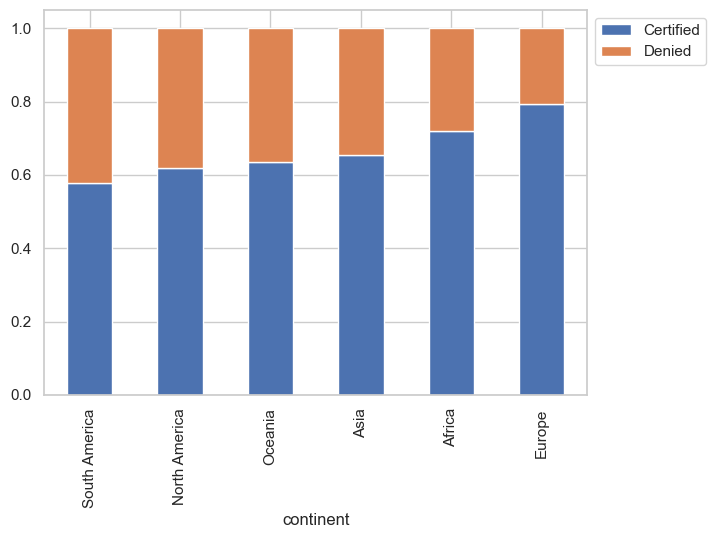

```python
# continent vs case_status
stacked_barplot(df, "continent", "case_status")
```

### Observations :

**Europe** has the **highest certification rate (~80%)**, indicating strong approval outcomes for applicants from this region.

**North America** and **South America** have **lower certification rates** (around **60–65%**), compared to other continents.

**Oceania** shows a moderate certification rate (~65%), but the overall number of applications is very small.

Overall, certification rates vary by region, suggesting that **continent may be an influential factor** in visa approval outcomes.

```
case_status            Certified  Denied    All
education_of_employee
All                        17018    8462  25480
Bachelor's                  6367    3867  10234
High School                 1164    2256   3420
Master's                    7575    2059   9634
Doctorate                   1912     280   2192
------------------------------------------------------------------------------------------------------------------------
```

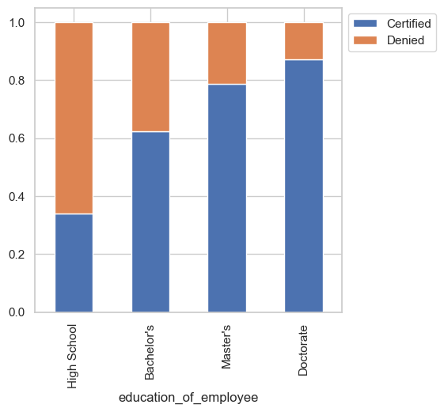

```python
# education_of_employee vs case_status
stacked_barplot(df, "education_of_employee", "case_status")
```

### Observations :

**Higher education levels have higher certification rates.**

**Doctorate holders** show the **highest approval rate (~88%)**, indicating strong acceptance for highly qualified applicants.

**Master’s degree applicants** also have a high certification rate (~78%).

**Bachelor’s degree holders** show a moderate approval rate (~63%).

**High School applicants** have the **lowest certification rate (~33%)**, indicating a clear disadvantage.

```
case_status         Certified  Denied    All
has_job_experience
All                     17018    8462  25480
N                        5994    4684  10678
Y                       11024    3778  14802
------------------------------------------------------------------------------------------------------------------------
```

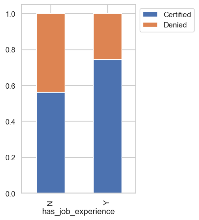

```python
# has_job_experience vs case_status
stacked_barplot(df, "has_job_experience", "case_status")
```

### Observations

Applicants **with job experience (Y)** have a **higher certification rate (~74%)**.

Applicants **without job experience (N)** have a **much lower certification rate (~56%)**.

Denial rates are noticeably higher for applicants **without experience**.

This indicates that **prior job experience positively influences visa approval**.

```
case_status            Certified  Denied    All
requires_job_training
All                        17018    8462  25480
N                          15012    7513  22525
Y                           2006     949   2955
------------------------------------------------------------------------------------------------------------------------
```

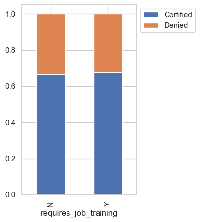

```python
# requires_job_training vs case_status
stacked_barplot(df, "requires_job_training", "case_status")
```

### Observations :

Applicants **requiring job training (Y)** also experience a **similar certification rate (~68%)**, with only a minor difference.

The approval rates for both groups are almost identical, suggesting that **job training requirement does not significantly impact visa certification outcomes**.

This feature appears to have **low predictive power** for determining case status.

```
case_status           Certified  Denied    All
region_of_employment
All                       17018    8462  25480
Northeast                  4526    2669   7195
West                       4100    2486   6586
South                      4913    2104   7017
Midwest                    3253    1054   4307
Island                      226     149    375
------------------------------------------------------------------------------------------------------------------------
```

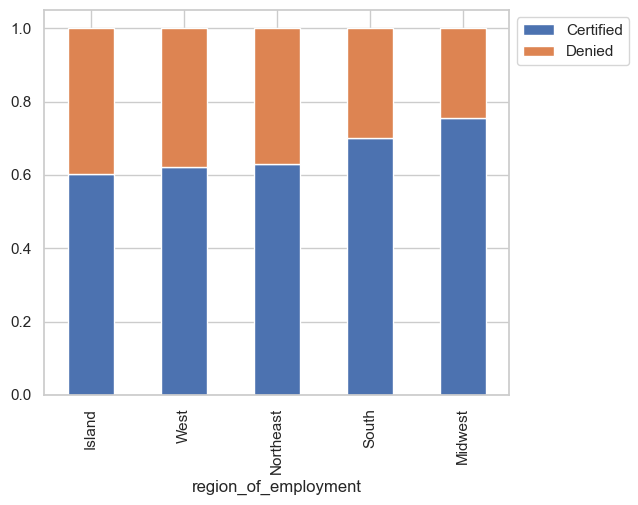

```python
# region_of_employment vs case_status
stacked_barplot(df, "region_of_employment", "case_status")
```

### Observations :

**Midwest** has the **highest certification rate (~75%)**, suggesting stronger approval outcomes in this region.

**Island region** has the **lowest certification rate (~60%)**, though the number of applications is very small.

Overall, the certification rate varies slightly across regions, but no extreme differences are observed (except Midwest is clearly stronger).

```
case_status   Certified  Denied    All
unit_of_wage
All               17018    8462  25480
Year              16047    6915  22962
Hour                747    1410   2157
Week                169     103    272
Month                55      34     89
------------------------------------------------------------------------------------------------------------------------
```

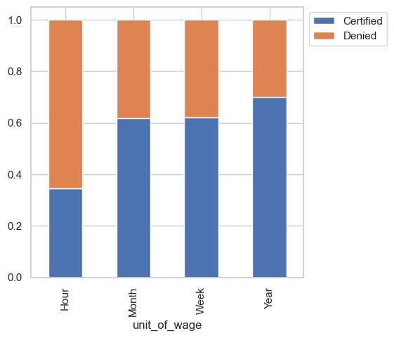

```python
# unit_of_wage vs case_status
stacked_barplot(df, "unit_of_wage", "case_status")
```

### Observations :

**Yearly wage unit** has the **highest certification rate (~70%)**, indicating stronger approval for positions paid annually.

**Monthly and Weekly** wage units show **moderate approval rates (~62%)**, slightly lower than yearly.

**Hourly wage** has the **lowest certification rate (~35%)**, showing that hourly positions are much more likely to be denied.

This indicates that **higher or more stable wage structures (Year > Month/Week > Hour)** are associated with **higher visa approval likelihood**.

```
case_status         Certified  Denied    All
full_time_position
All                     17018    8462  25480
Y                       15163    7610  22773
N                        1855     852   2707
------------------------------------------------------------------------------------------------------------------------
```

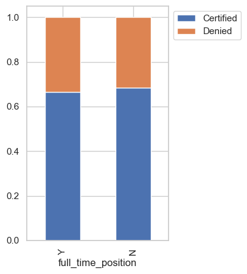

```python
# full_time_position vs case_status
stacked_barplot(df, "full_time_position", "case_status")
```

### Observations :

**Part-time positions (N)** show a **similar certification rate (~68%)**, but the sample size is much smaller.

Overall, **full-time vs part-time status does not show a strong impact** on visa certification.

The difference in approval rates between full-time and part-time roles is **minimal**, suggesting this feature has **low predictive influence**.

```python
df.head()
```

|  | continent | education_of_employee | has_job_experience | requires_job_training | no_of_employees | region_of_employment | prevailing_wage | unit_of_wage | full_time_position | case_status | company_age |
| --- | --- | --- | --- | --- | --- | --- | --- | --- | --- | --- | --- |
| 0 | Asia | High School | N | N | 14513 | West | 592.2029 | Hour | Y | Denied | 18.0 |
| 1 | Asia | Master's | Y | N | 2412 | Northeast | 83425.6500 | Year | Y | Certified | 23.0 |
| 2 | Asia | Bachelor's | N | Y | 44444 | West | 122996.8600 | Year | Y | Denied | 17.0 |
| 3 | Asia | Bachelor's | N | N | 98 | West | 83434.0300 | Year | Y | Denied | 27.0 |
| 4 | Africa | Master's | Y | N | 1082 | South | 149907.3900 | Year | Y | Certified | 20.0 |

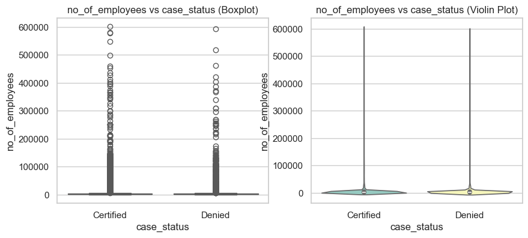

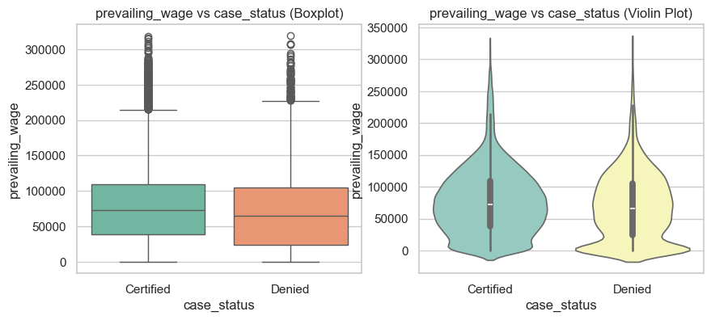

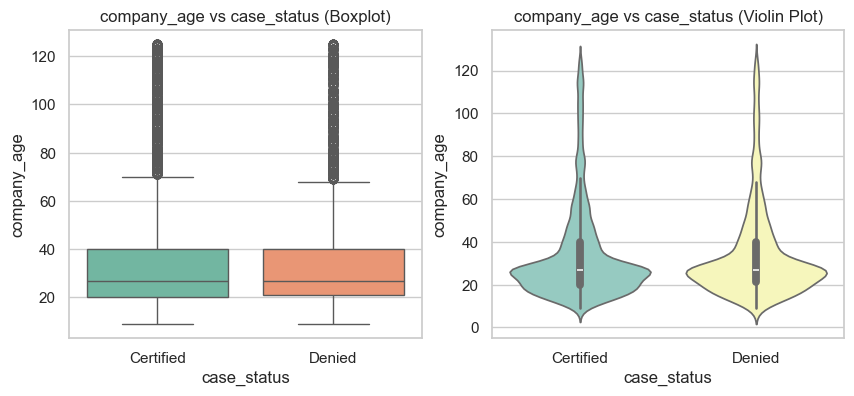

```python
# Finding the relationship with all the numeric columnns with taget variable.
numerical_cols = ['no_of_employees','prevailing_wage','company_age']
target = 'case_status'

# Numerical vs Target (boxplots + violin plots)
for col in numerical_cols:
    plt.figure(figsize=(10,4))
    plt.subplot(1,2,1)
    sns.boxplot(x=df[target], y=df[col], palette="Set2")
    plt.title(f'{col} vs {target} (Boxplot)')

    plt.subplot(1,2,2)
    sns.violinplot(x=df[target], y=df[col], palette="Set3")
    plt.title(f'{col} vs {target} (Violin Plot)')
    plt.show()
```

### Observations :

**no_of_employees vs case_status**

Both certified and denied applications show a highly skewed distribution with many extreme outliers.

No clear difference between the two groups, number of employees does NOT significantly impact visa approval.

**prevailing_wage vs case_status**

Certified cases have a slightly higher median prevailing wage compared to denied cases.

Overall, higher prevailing wage slightly increases approval chances.

**company_age vs case_status**

Company age distributions for both certified and denied cases look very similar.

No strong difference in median or spread.

Indicates that company age does NOT strongly influence visa certification.

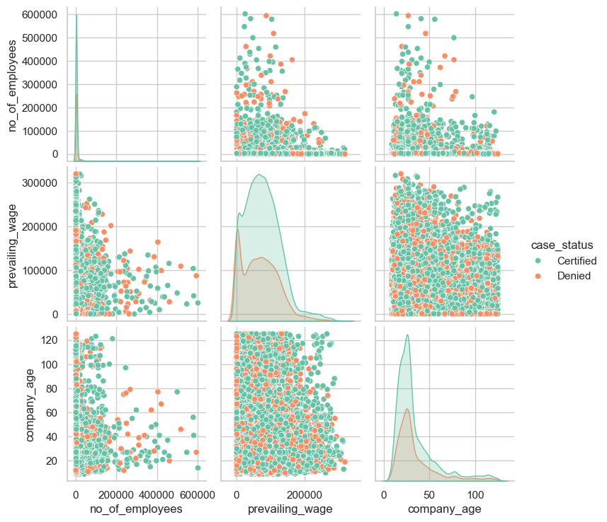

```python
# Pairplot for numerical features colored by target
sns.pairplot(df[numerical_cols + [target]], hue=target, palette="Set2")
plt.show()
```

### Observations :

**no_of_employees**

Extremely right-skewed with heavy outliers.

Certified and denied cases are mixed uniformly, meaning no_of_employees does NOT help distinguish case_status.

**prevailing_wage**

Certified applicants generally cluster slightly higher on the wage axis.

Higher wages show a marginally higher proportion of certified cases, indicating prevailing_wage has some predictive power.

However, both classes overlap heavily, wage alone cannot strongly separate them.

**company_age**

Most companies are young (0–40 years), with a long tail.

Certified and denied points are almost evenly mixed across all ages → company_age does NOT strongly influence approval.

**Relationship Between Features**

No strong linear correlation between no_of_employees, prevailing_wage, and company_age.

The scatter interactions show wide dispersion and no distinct clusters that separate certified vs denied.

## Data preprocessing

```python
# In the previous analysis, it was observed that some no_of_employees values were negative (–), which are invalid and should not occur.
df[df["no_of_employees"] < 0]
```

|  | continent | education_of_employee | has_job_experience | requires_job_training | no_of_employees | region_of_employment | prevailing_wage | unit_of_wage | full_time_position | case_status | company_age |
| --- | --- | --- | --- | --- | --- | --- | --- | --- | --- | --- | --- |
| 245 | Europe | Master's | N | N | -25 | Northeast | 39452.9900 | Year | Y | Certified | 45.0 |
| 378 | Asia | Bachelor's | N | Y | -11 | Northeast | 32506.1400 | Year | Y | Denied | 14.0 |
| 832 | South America | Master's | Y | N | -17 | South | 129701.9400 | Year | Y | Certified | 23.0 |
| 2918 | Asia | Master's | Y | N | -26 | Midwest | 112799.4600 | Year | Y | Certified | 20.0 |
| 6439 | Asia | Bachelor's | N | N | -14 | South | 103.9700 | Hour | Y | Denied | 12.0 |
| 6634 | Asia | Bachelor's | Y | N | -26 | West | 5247.3200 | Year | Y | Denied | 102.0 |
| 7224 | Europe | Doctorate | N | N | -25 | Midwest | 141435.9500 | Year | Y | Certified | 27.0 |
| 7281 | Asia | High School | N | N | -14 | Midwest | 58488.5000 | Year | Y | Denied | 25.0 |
| 7318 | Asia | Bachelor's | Y | Y | -26 | South | 115005.6100 | Year | Y | Certified | 19.0 |
| 7761 | Asia | Master's | N | N | -11 | Midwest | 38457.5100 | Year | Y | Certified | 16.0 |
| 9872 | Europe | Master's | Y | N | -26 | South | 37397.0500 | Year | Y | Certified | 29.0 |
| 11493 | Asia | High School | Y | N | -14 | South | 27599.3500 | Year | Y | Denied | 26.0 |
| 13471 | North America | Master's | N | N | -17 | Northeast | 257.2413 | Hour | Y | Denied | 22.0 |
| 14022 | Asia | Bachelor's | N | Y | -11 | Northeast | 108403.5600 | Year | Y | Certified | 79.0 |
| 14146 | Asia | Bachelor's | N | Y | -26 | West | 81982.2700 | Year | Y | Certified | 71.0 |
| 14726 | Asia | Master's | N | N | -11 | Midwest | 167851.8000 | Year | Y | Certified | 25.0 |
| 15600 | Asia | Bachelor's | N | N | -14 | South | 24641.6100 | Year | Y | Denied | 11.0 |
| 15859 | Asia | High School | N | N | -11 | South | 44640.6000 | Year | Y | Denied | 56.0 |
| 16157 | Asia | Master's | Y | N | -11 | South | 62681.2500 | Year | Y | Certified | 31.0 |
| 16883 | North America | Bachelor's | Y | N | -26 | Northeast | 168.1558 | Hour | Y | Denied | 57.0 |
| 17006 | Asia | Doctorate | Y | N | -11 | West | 25753.5100 | Year | Y | Denied | 41.0 |
| 17655 | North America | Bachelor's | Y | N | -17 | Northeast | 129753.1800 | Year | Y | Denied | 18.0 |
| 17844 | Asia | Bachelor's | N | N | -14 | West | 29325.8500 | Year | Y | Denied | 13.0 |
| 17983 | Asia | Bachelor's | N | N | -26 | South | 84359.9800 | Year | Y | Denied | 21.0 |
| 20815 | Asia | Bachelor's | N | Y | -17 | West | 91897.5700 | Year | Y | Certified | 35.0 |
| 20984 | Europe | Doctorate | Y | N | -14 | Midwest | 37012.8000 | Year | Y | Certified | 36.0 |
| 21255 | North America | High School | N | N | -25 | South | 99405.4700 | Year | N | Denied | 38.0 |
| 21760 | Asia | Bachelor's | Y | N | -25 | West | 100463.5800 | Year | Y | Certified | 25.0 |
| 21944 | Africa | Master's | Y | N | -25 | Midwest | 79150.5100 | Year | Y | Certified | 48.0 |
| 22084 | North America | Bachelor's | Y | N | -14 | West | 691.0609 | Hour | Y | Denied | 45.0 |
| 22388 | Asia | Master's | Y | N | -14 | South | 17893.1100 | Year | Y | Certified | 39.0 |
| 23186 | Asia | Master's | N | Y | -11 | Midwest | 120195.3500 | Year | Y | Certified | 18.0 |
| 23476 | Europe | Master's | Y | N | -11 | West | 95072.7500 | Year | Y | Denied | 25.0 |

```python
neg_percent = (df[df["no_of_employees"] < 0].shape[0] / len(df)) * 100
print(f"Percentage of negative values: {neg_percent:.2f}%")
```

```
Percentage of negative values: 0.13%
```

### Observation :

Only 0.13% of **no_of_employees** column contains negative. Hence dropping the entire rows where no_of_employees have negative values.

```python
# Dropping the entire rows where no_of_employees have negative values
df = df[df["no_of_employees"] >= 0].reset_index(drop=True)
```

## FEATURE ENGINEERING & DATA PREPARATION FOR MODELLING

```python
from sklearn.model_selection import train_test_split
from sklearn.preprocessing import StandardScaler
```

```python
# Dropping duplicate row if any.

df = df.drop_duplicates()
```

**Encoding target variable**

```python
# Label encoding the target varibale.
df['case_status'] = df['case_status'].map({'Certified': 1, 'Denied': 0})
```

```python
df.head()
```

|  | continent | education_of_employee | has_job_experience | requires_job_training | no_of_employees | region_of_employment | prevailing_wage | unit_of_wage | full_time_position | case_status | company_age |
| --- | --- | --- | --- | --- | --- | --- | --- | --- | --- | --- | --- |
| 0 | Asia | High School | N | N | 14513 | West | 592.2029 | Hour | Y | 0 | 18.0 |
| 1 | Asia | Master's | Y | N | 2412 | Northeast | 83425.6500 | Year | Y | 1 | 23.0 |
| 2 | Asia | Bachelor's | N | Y | 44444 | West | 122996.8600 | Year | Y | 0 | 17.0 |
| 3 | Asia | Bachelor's | N | N | 98 | West | 83434.0300 | Year | Y | 0 | 27.0 |
| 4 | Africa | Master's | Y | N | 1082 | South | 149907.3900 | Year | Y | 1 | 20.0 |

**Outlier Treatment**

```python
#  As it is seen in EDA that all the three numeric features all no_of_employees, prevailing_wage and company_age right skewed with outliers.
df["no_of_employees_log"] = np.log1p(df["no_of_employees"])
df["prevailing_wage_log"] = np.log1p(df["prevailing_wage"])
df["company_age_log"] = np.log1p(df["company_age"])
```

```python
df.drop(columns=["no_of_employees", "prevailing_wage", "company_age"], inplace=True)
```

**Encoding independent variable**

```python
target = "case_status"

cat_cols = df.select_dtypes(include=['category']).columns.tolist()
if target in cat_cols:
    cat_cols.remove(target)

cat_cols
```

```
['continent',
 'education_of_employee',
 'has_job_experience',
 'requires_job_training',
 'region_of_employment',
 'unit_of_wage',
 'full_time_position']
```

```python
# Encoding the independent variable using LabelEncoder
from sklearn.preprocessing import LabelEncoder

le = LabelEncoder()

for col in cat_cols:
    df[col] = le.fit_transform(df[col])
```

**Feature Scaling**

```python
from sklearn.preprocessing import StandardScaler
```

```python
# Scaling only numerical continuous variables
scaler = StandardScaler()
scale_cols = ['no_of_employees_log','prevailing_wage_log','company_age_log']
df[scale_cols] = scaler.fit_transform(df[scale_cols])
```

**Plotting the heatmap**

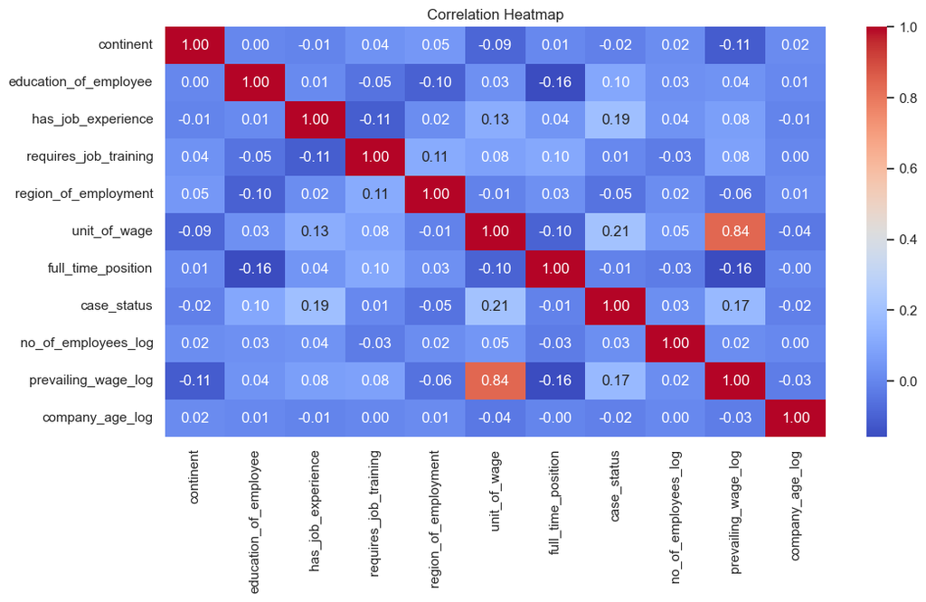

```python
# Plotting the correlation heatmap.
plt.figure(figsize=(12,6))
sns.heatmap(df.corr(), annot=True, cmap="coolwarm", fmt=".2f")
plt.title("Correlation Heatmap")
plt.show()
```

### Observations :

**1 Very Weak Correlation With Target (case_status)**

Most features show **very low correlation** (near zero) with **case_status**.

The strongest (but still weak) correlations are:

👉 This means **no single feature strongly predicts visa approval**, so a machine learning model is needed to capture combined effects.

**2 High Correlation Between Some Independent Features**

Meaning wage paid per hour/month/week/year has a strong relationship with the wage amount.

This indicates **multicollinearity**; one of them may be dropped in linear models.

**3 Other Features Show Weak Intercorrelations**

**no_of_employees_log, company_age_log,** and other categorical features show **very weak relationships** with each other.

This suggests the features are mostly independent, which is good for tree models.

**4 Overall Insight**

Most other features show correlations close to 0, meaning the dataset has **no strong linear patterns**.

ML models like Random Forest, XGBoost, or Logistic Regression with interactions will perform better than simple linear correlation analysis.

```python
# Assigning the Variable to X and y

X = df.drop('case_status', axis=1)
y = df['case_status']
```

```python
# VIF (Variance Inflation Factor) Calculation

from statsmodels.stats.outliers_influence import variance_inflation_factor
import statsmodels.api as sm

X = sm.add_constant(X)
vif_data = pd.DataFrame()
vif_data["Variable"] = X.columns
vif_data["VIF"] = [variance_inflation_factor(X.values, i) for i in range(X.shape[1])]

vif_data
```

|  | Variable | VIF |
| --- | --- | --- |
| 0 | const | 52.147365 |
| 1 | continent | 1.018297 |
| 2 | education_of_employee | 1.038220 |
| 3 | has_job_experience | 1.041083 |
| 4 | requires_job_training | 1.057900 |
| 5 | region_of_employment | 1.035493 |
| 6 | unit_of_wage | 3.440728 |
| 7 | full_time_position | 1.071889 |
| 8 | no_of_employees_log | 1.007005 |
| 9 | prevailing_wage_log | 3.479352 |
| 10 | company_age_log | 1.002106 |

### Observations :

All variables have VIF values below 5, indicating no multicollinearity issue in the dataset. Only unit_of_wage and prevailing_wage_log show mild correlation, but still remain within acceptable limits. Overall, the predictors are independent and safe to use for modeling.

## Model Building - Original Data

#### Recall test score is important for Business problem.

**Because in this problem, the cost of missing a Certified case is high.**

A **false negative** means:

The model predicts Denied

But the actual case is Certified

- A qualified applicant gets wrongly filtered out
- Business loses a valid worker
- OFLC process becomes inefficient

This is more harmful than a false positive.

```python
from sklearn.model_selection import train_test_split

X_train, X_test, y_train, y_test = train_test_split(X, y, test_size=0.3, random_state=42, stratify=y)
```

**Writing the user define function for model prediction and confusion matrix score.**

```python
model_names = []
accuracy_scores = []
precision_scores = []
recall_scores = []
f1_scores = []

def train_and_evaluate_model(model):
    # Fit model
    model.fit(X_train, y_train)

    # Predictions
    y_pred_train = model.predict(X_train)
    y_pred_test = model.predict(X_test)

    # Train scores
    train_acc = accuracy_score(y_train, y_pred_train)
    train_precision = precision_score(y_train, y_pred_train)
    train_recall = recall_score(y_train, y_pred_train)
    train_f1 = f1_score(y_train, y_pred_train)

    # Test scores
    test_acc = accuracy_score(y_test, y_pred_test)
    test_precision = precision_score(y_test, y_pred_test)
    test_recall = recall_score(y_test, y_pred_test)
    test_f1 = f1_score(y_test, y_pred_test)

    # Print Train Results
    print("\n================ TRAINING PERFORMANCE ================")
    print(classification_report(y_train, y_pred_train))
    print("Train Accuracy:", train_acc)
    print("Train Precision:", train_precision)
    print("Train Recall:", train_recall)
    print("Train F1 Score:", train_f1)

    # Print Test Results
    print("\n================ TEST PERFORMANCE ================")
    print(classification_report(y_test, y_pred_test))
    print("Test Accuracy:", test_acc)
    print("Test Precision:", test_precision)
    print("Test Recall:", test_recall)
    print("Test F1 Score:", test_f1)

    # Confusion Matrix (Train)
    print("\nConfusion Matrix - TRAIN DATA")
    ConfusionMatrixDisplay.from_predictions(y_train, y_pred_train)
    plt.show()

    # Confusion Matrix (Test)
    print("\nConfusion Matrix - TEST DATA")
    ConfusionMatrixDisplay.from_predictions(y_test, y_pred_test)
    plt.show()

    # Store test scores
    model_names.append(model)
    accuracy_scores.append(test_acc)
    precision_scores.append(test_precision)
    recall_scores.append(test_recall)
    f1_scores.append(test_f1)
```

```python
#Importing necessary library for model prediction and confusion matrix score.

from sklearn.metrics import ConfusionMatrixDisplay, classification_report, precision_score, recall_score, accuracy_score, f1_score
from sklearn.tree import DecisionTreeClassifier
from xgboost import XGBClassifier
from sklearn.ensemble import RandomForestClassifier, AdaBoostClassifier, GradientBoostingClassifier, BaggingClassifier
```

**Decision Tree Classifier**

```
================ TRAINING PERFORMANCE ================
              precision    recall  f1-score   support

           0       1.00      1.00      1.00      5912
           1       1.00      1.00      1.00     11900

    accuracy                           1.00     17812
   macro avg       1.00      1.00      1.00     17812
weighted avg       1.00      1.00      1.00     17812

Train Accuracy: 1.0
Train Precision: 1.0
Train Recall: 1.0
Train F1 Score: 1.0

================ TEST PERFORMANCE ================
              precision    recall  f1-score   support

           0       0.47      0.48      0.47      2534
           1       0.74      0.74      0.74      5101

    accuracy                           0.65      7635
   macro avg       0.60      0.61      0.61      7635
weighted avg       0.65      0.65      0.65      7635

Test Accuracy: 0.6489849377865095
Test Precision: 0.7383343177790904
Test Recall: 0.7351499705940012
Test F1 Score: 0.7367387033398821

Confusion Matrix - TRAIN DATA
```

```
Confusion Matrix - TEST DATA
```

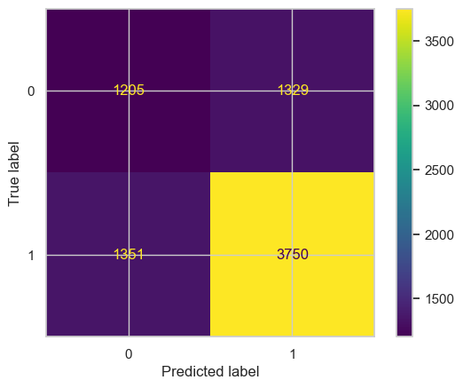

```python
train_and_evaluate_model(DecisionTreeClassifier())
```

[output not shown]

### Observations :

Model is overfitting.

```
================ TRAINING PERFORMANCE ================
              precision    recall  f1-score   support

           0       1.00      1.00      1.00      5912
           1       1.00      1.00      1.00     11900

    accuracy                           1.00     17812
   macro avg       1.00      1.00      1.00     17812
weighted avg       1.00      1.00      1.00     17812

Train Accuracy: 1.0
Train Precision: 1.0
Train Recall: 1.0
Train F1 Score: 1.0

================ TEST PERFORMANCE ================
              precision    recall  f1-score   support

           0       0.48      0.48      0.48      2534
           1       0.74      0.74      0.74      5101

    accuracy                           0.66      7635
   macro avg       0.61      0.61      0.61      7635
weighted avg       0.65      0.66      0.66      7635

Test Accuracy: 0.6555337262606418
Test Precision: 0.741167284794066
Test Recall: 0.744363850225446
Test F1 Score: 0.7427621283255086

Confusion Matrix - TRAIN DATA
```

```
Confusion Matrix - TEST DATA
```

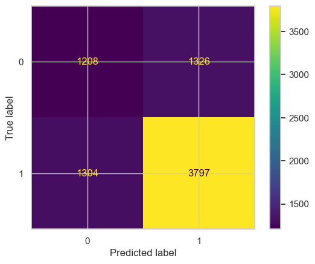

```python
# Decision tree with class weight assignment.
train_and_evaluate_model(DecisionTreeClassifier(criterion='gini',class_weight={0:0.67,1:0.33},random_state=1))
```

[output not shown]

**Random Forest Classifier**

```
================ TRAINING PERFORMANCE ================
              precision    recall  f1-score   support

           0       1.00      1.00      1.00      5912
           1       1.00      1.00      1.00     11900

    accuracy                           1.00     17812
   macro avg       1.00      1.00      1.00     17812
weighted avg       1.00      1.00      1.00     17812

Train Accuracy: 1.0
Train Precision: 1.0
Train Recall: 1.0
Train F1 Score: 1.0

================ TEST PERFORMANCE ================
              precision    recall  f1-score   support

           0       0.61      0.51      0.55      2534
           1       0.77      0.84      0.81      5101

    accuracy                           0.73      7635
   macro avg       0.69      0.67      0.68      7635
weighted avg       0.72      0.73      0.72      7635

Test Accuracy: 0.7299279633267846
Test Precision: 0.7741295327440014
Test Recall: 0.8412076063516958
Test F1 Score: 0.8062758361518226

Confusion Matrix - TRAIN DATA
```

```
Confusion Matrix - TEST DATA
```

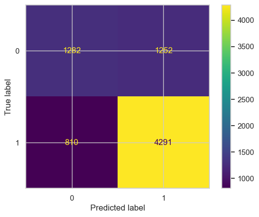

```python
train_and_evaluate_model(RandomForestClassifier())
```

[output not shown]

### Observations :

Model is overfitting.

**Bagging Classifier**

```
================ TRAINING PERFORMANCE ================
              precision    recall  f1-score   support

           0       0.97      0.98      0.98      5912
           1       0.99      0.99      0.99     11900

    accuracy                           0.98     17812
   macro avg       0.98      0.98      0.98     17812
weighted avg       0.98      0.98      0.98     17812

Train Accuracy: 0.9839995508645857
Train Precision: 0.9898776887389287
Train Recall: 0.9861344537815127
Train F1 Score: 0.9880025257840455

================ TEST PERFORMANCE ================
              precision    recall  f1-score   support

           0       0.55      0.54      0.55      2534
           1       0.78      0.78      0.78      5101

    accuracy                           0.70      7635
   macro avg       0.66      0.66      0.66      7635
weighted avg       0.70      0.70      0.70      7635

Test Accuracy: 0.7018991486574984
Test Precision: 0.775180206506916
Test Recall: 0.7800431287982749
Test F1 Score: 0.7776040648817667

Confusion Matrix - TRAIN DATA
```

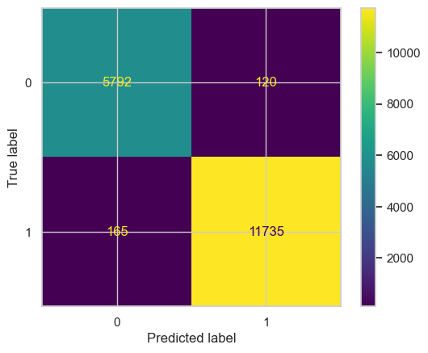

```
Confusion Matrix - TEST DATA
```

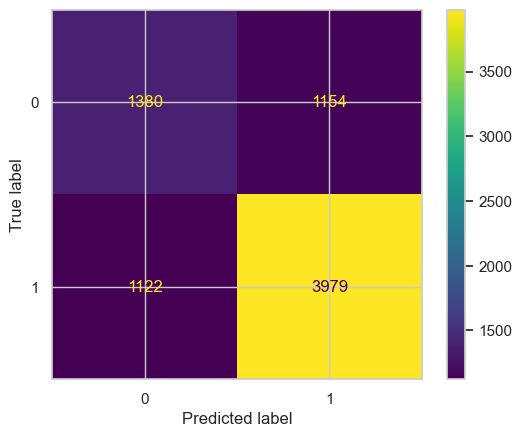

```python
train_and_evaluate_model(BaggingClassifier())
```

### Observations :

Model is overfitting.

**Gradient Boosting Classifier**

```
================ TRAINING PERFORMANCE ================
              precision    recall  f1-score   support

           0       0.68      0.49      0.57      5912
           1       0.78      0.88      0.83     11900

    accuracy                           0.75     17812
   macro avg       0.73      0.69      0.70     17812
weighted avg       0.74      0.75      0.74     17812

Train Accuracy: 0.7537053671682012
Train Precision: 0.7784036166901356
Train Recall: 0.8826050420168067
Train F1 Score: 0.8272358524002678

================ TEST PERFORMANCE ================
              precision    recall  f1-score   support

           0       0.66      0.50      0.57      2534
           1       0.78      0.87      0.82      5101

    accuracy                           0.75      7635
   macro avg       0.72      0.69      0.70      7635
weighted avg       0.74      0.75      0.74      7635

Test Accuracy: 0.7489194499017682
Test Precision: 0.777448588358313
Test Recall: 0.8745344050186238
Test F1 Score: 0.8231386659285912

Confusion Matrix - TRAIN DATA
```

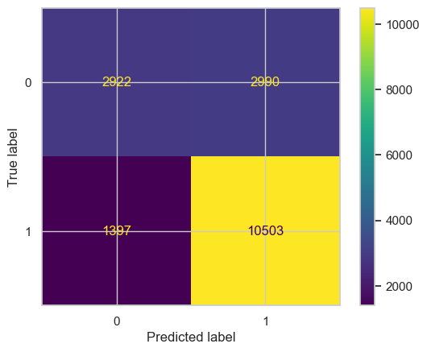

```
Confusion Matrix - TEST DATA
```

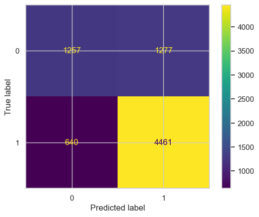

```python
train_and_evaluate_model(GradientBoostingClassifier())
```